# Aside

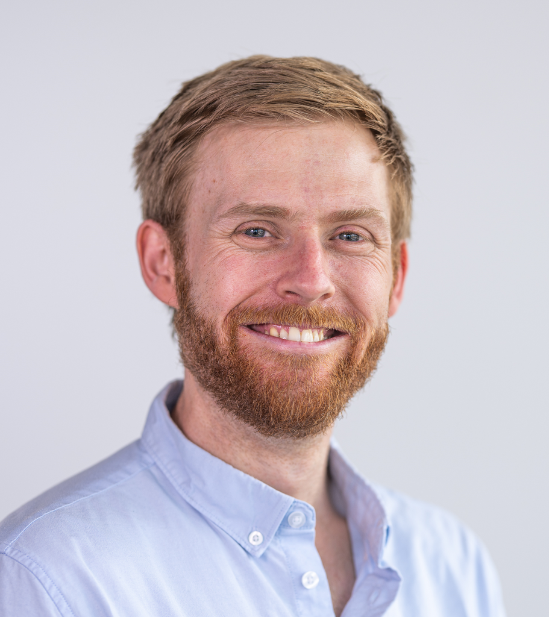

## Contact Info

- Postdoctoral researcher
- [ETH Planning of Landscape and Urban systems](https://plus.ethz.ch/)
- Zurich, Switzerland
- bblack[at]ethz[dot]ch
- [blenback.github.io](https://blenback.github.io/)
- 0000-0002-8113-2114
- ben-black-9889a1150
- blenback
- Blen_Back
- https://www.researchgate.net/profile/Benjamin-Black-5

## Technical Skills

- *Advanced:* R (Shiny, Quarto), Dinamica EGO, Netica and MS Office
- *Intermediate:* ArcGIS, QGIS, CSS and Git
- *Basic:* Python, HTML, Docker, JavaScript, Bash and Slurm

## Languages

- *English:* Native
- *German:* B2

# Main

## Benjamin Black

Postdoctoral researcher with a professional background in conservation, specialising in socio-environmental systems modelling to support evidence-based policy and planning. Passionate about advancing open science, communicating research beyond academia, and mentoring others in modelling, programmatic data analysis, and visualisation. Experienced in managing small and large teams, especially in cross-cultural and interdisciplinary settings, with a strong commitment to collaborative and inclusive research.

## Education

### Doctor of Civil Engineering

ETH Zürich, chair of Planning of Landscape Urban Systems (PLUS)

Zürich, Switzerland

Oct. 2020 - Jun. 2025

Thesis: *[Identifying effective area-based conservation strategies under uncertainties](https://blenback.github.io/presentations/2025_05_6_PhD_defence/)*

Awards: *Nominated for the ETH medal for outstanding doctoral theses*

### MSc in Environmental Sciences, Policy and Management (MESPOM)

Central European University, University of Manchester, Lund University, University of the Aegean

Hungary, Greece, UK

Sep. 2018 - Jun. 2020

Thesis: *[Assessing the ecological effectiveness of protected areas in Cambodia: a quasi-experimental counterfactual estimation of avoided deforestation](http://dx.doi.org/10.13140/RG.2.2.28621.10727)*

Awards: *Outstanding academic achievement (highest GPA in cohort: 4.00/4.00)*

### BSc with 1st Class Honours in Biological Sciences

Edinburgh Napier University

Edinburgh, Scotland

Sep. 2010 - Jun. 2014

Thesis: *[Simulating the future potential of degraded Mangrove plots using field data from Kenya](http://dx.doi.org/10.13140/RG.2.2.20232.49923)*

Awards: *University medal (highest average mark on degree route); Lawrence Ho student prize; Dennis Aw award.*

## Professional Experience

### Freelance Research Consultant

Prognos AG

Zürich, Switzerland

May. 2025 - Jul. 2025

*Performed Land Use and Land Cover change modelling of Shared Socioeconomic Pathways for Switzerland as part of project funded by the Swiss National Centre for Climate Services*

### Biodiversity and SMART Intern

The Wildlife Conservation Society (WCS)

Phnom Penh, Cambodia

Jul. 2019 - Aug. 2019

*Developed a programmatic routine to expedite the collection of external data from the IUCN, EDGE ranking and CITES to produce protected area species inventories in line with Darwin Core standards. Assisted in the training of new community biodiversity rangers in the process of SMART data collection in the field.*

### Student Affairs Manager

The School for Field Studies Center for Conservation and Development Studies in the Lower Mekong

Siem Reap, Cambodia

Jan. 2018 - Aug. 2018

*Coordinated safety and risk management as well as logistics for all centre activities including multi day field trips to remote locations. Served as the medical point person, facilitating first aid training for staff, while also supporting student well-being and cultural adaptation in a pastoral role.*

### Project Manager & Volunteer Co-ordinator

Elephant Livelihood Initiatives and Environment (E.L.I.E)

Mondulkiri, Cambodia

April. 2015 - June. 2017

*Managed a diverse team (Bunong Indigenous minority, and Khmer) of 48 staff. Oversaw the operation of an ecotourism project receiving 4000+ visitors a year. Facilitated ongoing capacity building of staff and development of the volunteer program. Compiled budgets, managed cash flow, and created detailed financial and organizational reports.*

### Independent Consultant Srae Y Community ecotourism project

World Wide Fund for Nature (WWF)

Mondulkiri, Cambodia

Oct. 2015 - Dec. 2015

*Undertook site visits to assess the status of the project and prepared a report, detailing strategies to make the project operational and sustainable. Planned and delivered a series of training sessions to project staff and stakeholders from other communities engaged in ecotourism.*

### Volunteer Development Officer & Conservation Support Assistant

The Conservation Volunteers (TCV)

Central Scotland

May 2013 - Apr. 2015

*Planned, developed and delivered the Ochils Landscape Partnerships volunteering program and two TCV community health projects. Engaged with, and ensured the safety and wellbeing of a diverse cross section of volunteers, many with physical or mental disabilities as well as young adults/children.*

## Teaching, Training & Workshop Delivery

### Reproducible Research with R and Quarto: Workflows for data, projects and publications

*Three hour workshop as part of Landscape 2024 conference*

Berlin, Germany

Sep. 2024

[Website](https://blenback.github.io/R-for-Reproducible-Research/)

### Participatory Environmental Modelling: MSc course at ETH Zürich

*Designed and taught an MSc-level course integrating students and practitioners to develop simulation models for real-world environmental decision-making.*

Zürich, Switzerland

Feb. 2021 - Jul. 2024

## Grants & Funding

### Future development of biodiversity and ecosystem services as a basis for the revision of the sectoral plan for biodiversity

Canton of Bern Department of Agriculture and Nature

Bern, Switzerland

Dec. 2024

*Project in collaboration with the Wyss Academy for Nature to generate policy-relevant evidence supporting the canton’s revision of the sectoral biodiversity plan.*

### NAture-positive SCenarios for ENvironmental Transitions Peru (NASCENT-PERU)

Swiss Re Foundation

Zürich, Switzerland

Jun. 2023

*Funded project under the SwissRE Biodiversity and Ecosystem Services Scenarios Modelling Initiative*

[Website](https://plus.ethz.ch/research/forschungsprojekte/NASCENT-PERU.html/)

## Publications

### The PAVE pathway: how to talk about models with people who did(n’t) build them

Bell, A., Troost, C., Filatova, T., Vincenot, C., Qin, C., Fiedler, S., Lemmen, C., Lynch, I., Pierce, M., Edmonds ,B., McIntire, E., Wang, H., Koralewski, T., Grant, W., Wang, M., Black, B., Grimm, V.

N/A

In Review

*Bioscience*

### Where will the change come from? Identifying decision-relevant factors in future Land Use and Cover Change ({LUCC}) scenarios to support planning under uncertainty

Roman, O., Adey, B., Black, B. and Zeindl, E.

N/A

In Review

*Futures*

### Temporal Archetypes of Nature’s Contributions to People for Sustainable Landscape Development

Wicki, S., Black, B., Külling, N., Kurmann, M., Wang, J., Lehmann, A., Gret-Regamey, A.

N/A

In Review

*Regional Environmental Change*

### Identifying robust conservation stragies to secure ecosystem service provision under uncertainties

Black, B. and Adde, A. and Külling, N. and Büth, C. and Kurmann, M. and Lehmann, A. and Altermatt, F. and Guisan, A. and Gret-Regamey, A.

N/A

In Review

*Journal of Environmental Management*

### Broadening the horizon in land use change modelling: Normative scenarios for nature positive futures in Switzerland

Black, B. and Adde, A. and Farinotti, D. and Guisan, A. and Külling, N. and Kurmann, M. and Martin, C. and Mayer, P. and Rabe, S and Streit, J. and Zekollari, H. and Grêt-Regamey, A.

N/A

2024

*Regional Environmental Change*

[Read](https://doi.org/10.1007/s10113-024-02261-0) [Data](https://doi.org/10.5281/zenodo.8263509) [Code](https://doi.org/10.5281/zenodo.12698471)

### Archetypes of social-ecological-technological systems for managing ecological infrastructure

Wicki, S. and Black, B. and Kurmann, M. and Grêt-Regamey, A.

N/A

2023

*Environmental Research Letters*

[Read](https://10.1088/1748-9326/ad1080)

### Re-considering the status quo: Improving calibration of land use change models through validation of transition potential predictions

Black, B. and van Strien, M. J. and Adde, A. and Grêt-Regamey, A.

N/A

2023

*Environmental Modelling & Software*

[Read](https://10.1016/j.envsoft.2022.105574) [Code](https://doi.org/10.5281/zenodo.10171467)

### Counterfactual assessment of protected area avoided deforestation in Cambodia: Trends in effectiveness, spillover effects and the influence of establishment date

Black, B. and Anthony, B. P.

N/A

2022

*Global Ecology and Conservation*

[Read](https://10.1016/j.gecco.2022.e02228) [Data](https://zenodo.org/record/6554206#.Y7V79ZDYo2w)

## Presentations

### A “Scope, Simulation and Story” approach to identify future spatial development scenarios

Computational Urban Planning and Urban Management Conference 2025

University College London

Jun. 2025

[Slides](https://virtual.oxfordabstracts.com/event/73503/submission/383)

### Negotiating scenarios of a desirable ecological infrastructure for Switzerland

4th Swiss Landscape Congress

Tramelan, Switzerland

Sep. 2024

[Slides](https://blenback.github.io/presentations/2024_5_9_Landschaft/)

### Normative scenarios of landscape change for Nature-Positive futures in Peru

World Biodiversity Forum

Davos, Switzerland

Jun. 2024

[Slides](https://blenback.github.io/presentations/2024_20_6_WBF/)

### Exploratory modelling of stochastic land use cover change (LUCC) future scenarios for spatial planning

10th Annual Conference of the Society for Decision Making Under Deep Uncertainty (DMDU 2023)

Delft, Netherlands

Nov. 2023

### Broadening the scope of future visions for nature positive futures in Peru

Swiss Re Institute Resilience Summit 2023

Zürich, Switzerland

Nov. 2023

[Slides](https://blenback.github.io/presentations/2023_11_30_SwissRE/)

### Characterising non-stationarity in predictive models of land use in Swiss mountain parks to inform scenarios for deliberative transformation

International Mountain conference 2022

Innsbruck, Austria

Sep. 2022

[Slides](https://blenback.github.io/presentations/2022_09_13_IMC/)

### ValPar.CH: Integrating land use change, Ecosystem Service and Biodiversity modelling to simulate pathways for a functioning Ecological Infrastructure for Switzerland

11th International Environmental Modelling and Software Society conference

Brussels, Belgium

Jul. 2022

[Slides](https://blenback.github.io/presentations/2022_07_01_IEMSs_ValParCH_pres/)

### Combining filter and embedded approaches to improve variable selection in land use change Cellular Automata models

11th International Environmental Modelling and Software Society conference

Brussels, Belgium

Jul. 2022

[Slides](https://blenback.github.io/presentations/2022_07_01_IEMSs_model_pres/)

### Ex-ante identification of policy interventions to secure a functioning ecological infrastructure: A participatory Bayesian Network approach in Switzerland

3rd Ecosystem Services Partnership Europe Regional conference

Tartu, Estonia

[Slides](https://blenback.github.io/presentations/2021_06_09_ESP/)

## Disclaimer

Last updated on 2025-12-04.